# **SkyTrax: Passenger Reviews of Airline Seats**

Noel Kaso

30/10/2020

# **DESCRIPTION**

### Exploring airline seat reviews

The [SkyTrax](https://www.airlinequality.com) website allows passengers to review many aspects of air travel, originally created as an independent customer forum, it has become a leading review site for airlines, airports and associated reviews (SkyTrax, n.d).

This report considers passenger airline seat reviews and seeks to answer a series of questions about these reviews with respect to the major airlines and aircraft types. Moreover, it is interesting to explore whether passenger ratings across a number of sub-criteria, or categories, correlate with their overall rating of the airline seat. There maybe a category rating that closely aligns with the overall rating and this might offer insights into the factors that determine a passenger review rating.

# **QUESTIONS**

### The Questions

1. Which airlines are the most frequently rated and which shows the best Overall Rating performance?
2. How does the variable Overall Rating vary amoungst the most frequently rated airlines?
3. How is the average of the Category Ratings distributed across the most frequently rated airlines?
4. How does Overall Rating vary between the major aircraft makes: Boeing and Airbus?
5. Which aircraft models show the best Overall Rating results?
6. What relationship exists between the Average Overall Rating and the Average Category Ratings and can the Average Overall Rating be predicted by one of more of these variables?

# **EXPLANATION**

### An expalation of the data set

The data set considered contains airlines passenger reviews of aircraft seats. The data was scraped in 2015 from [SkyTrax](https://www.airlinequality.com). The set contains 1,258 reviews (observations) comprising 21 variables, including the passenger rating of the airline seat overall (score out of 10) and a rating over a number of categories (score out of 5). These ratings are referred to, in this report, as the Category Ratings and cover: seat legroom, width, recline, aisle space, viewing tv, power supply and seat storage. The airline name, aircraft make and model are also captured. Whether the passenger would recommend the airline seat, or not, is captured in the variable Recommended as numeric indicator.

Four variables exhibited a degree of missingness (Tierney, 2019) greater than 90% and these were excluded from the analysis. Passenger reviews where the category rating variable Viewing TV Rating was missing occurred to a low degree, therefore these observations were removed from analysis by filtering. Overall the variables most relevant to the questions are 100% present in the data set.

### Approach to tidying and wrangling

Variables relevant to the questions were included in the tidy data using the Select (Grolemund,Wickham, n.d) function - this allowed for focus on the variables relevant to the questions posed.

The variable Aircraft was split into Aircraft Make and Aircraft Model using the Separate function (Grolemund,Wickham, n.d). The consistency of the values stored in these two new variables was improved using three Mutate (Grolemund,Wickham, n.d) operations with if_else functions (Wickham,François,Henry,Müller, n.d). String Replace and Remove (Wickham,2019) allowed for the values in the new variables to be improved by removing non-alphanumeric characters and giving a single string value without additional characters of sub-model descriptors such as “-200LR”, “-300W”.

Filtering (Grolemund,Wickham, n.d) was applied to the Aircraft Make variable as the questions posed relate to Boeing and Airbus.

The tidied data set contains 1,226 observations across 14 variables relevant to the questions posed.

### Calculating an average of categroy ratings for each row

To calculate the average of the category ratings for each review a row-wise (Wickham,François,Henry,Müller,n.d) process was required with the Mutate function (Grolemund,Wickham, n.d). This is set-out in Question 3.

Further explanations of the approach to the tidy data set are set-out in the following sections for each question.

# **METHODS AND VISUALISATIONS**

### Working with the data

This section set-out the methods used to read, wrangle and tidy the data set. Firstly, a visualisation of missingness has been considered using the vis_miss function (Tierney, 2019). Then a tidy data set has been formed (seats_tidy) and further methods applied under each question.

#### Read the data

```r
# Read the CSV data
seats <- read_csv("https://raw.githubusercontent.com/quankiquanki/skytrax-reviews-dataset/master/data/seat.csv")
# Examine the raw data
glimpse(seats)
```

```
## Rows: 1,258
## Columns: 21
## $ airline_name        <chr> "aegean-airlines", "aegean-airlines", "aer-lingus…
## $ link                <chr> "/seat-reviews/aegean-airlines", "/seat-reviews/a…
## $ title               <chr> "Aegean Airlines customer review", "Aegean Airlin…
## $ author              <chr> "Jay Simpson", "Paul Staples", "L Pulliam", "D Br…
## $ author_country      <chr> "United Kingdom", "United Kingdom", "United State…
## $ date                <date> 2015-07-20, 2013-01-21, 2015-07-07, 2010-10-22, …
## $ content             <chr> "LHR to Larnaca return. Plane was clean and in go…
## $ aircraft            <chr> "A320-200", "AIRBUS A320", "A330", "Airbus A330",…
## $ seat_layout         <chr> "3x3", "3x3", "2x4x2", "2x4x2", "3x3", "2-4-2", "…
## $ date_flown          <chr> "19-07-2015", NA, "06-07-2015", NA, "01-07-2015",…
## $ cabin_flown         <chr> "Economy", "Economy", "Economy", "Economy", "Econ…
## $ type_traveller      <chr> "Solo Leisure", NA, "Couple Leisure", NA, "Busine…
## $ overall_rating      <dbl> 10, 9, 6, 5, 1, 9, 6, 4, 7, 6, 9, 10, 1, 7, 1, 2,…
## $ seat_legroom_rating <dbl> 4, 4, 3, 2, 1, 5, 4, 2, 3, 3, 5, 5, 1, 3, 1, 1, 4…
## $ seat_recline_rating <dbl> 4, 4, 3, 3, 1, 3, 4, 1, 3, 3, 5, 4, 3, 3, 1, 2, 4…
## $ seat_width_rating   <dbl> 4, 4, 3, 3, 1, 5, 4, 3, 3, 3, 4, 4, 3, 3, 3, 2, 3…
## $ aisle_space_rating  <dbl> 5, 4, 3, 3, 2, 5, 3, 2, 4, 3, 3, 5, 1, 3, 1, 1, 4…
## $ viewing_tv_rating   <dbl> 4, 4, 3, 4, 1, 5, 3, 0, 4, 0, 0, 5, 2, 3, 2, 2, 4…
## $ power_supply_rating <dbl> NA, NA, 3, NA, 5, 5, NA, NA, NA, NA, NA, NA, NA, …
## $ seat_storage_rating <dbl> 4, NA, 3, NA, 1, 5, NA, NA, NA, NA, NA, NA, NA, N…
## $ recommended         <dbl> 1, 1, 1, 0, 1, 1, 1, 0, 1, 0, 1, 1, 0, 1, 0, 0, 1…
```

#### Examine missing data

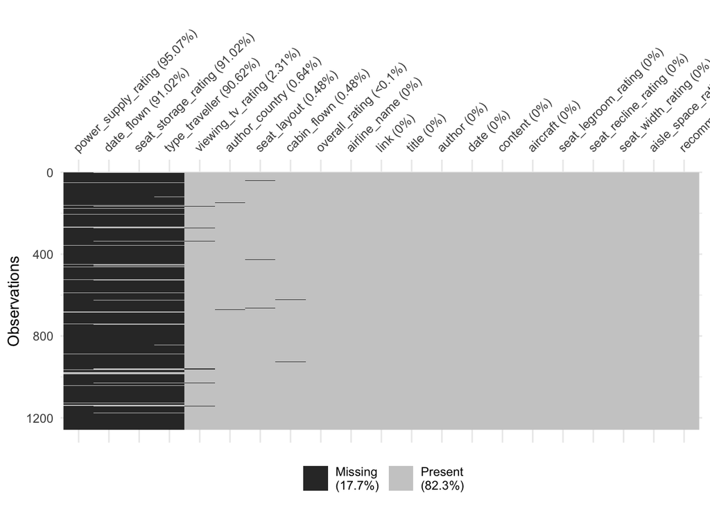

```r
vis_miss(seats, sort_miss = TRUE)
```

In the data set four variables exhibit a very high degree of missingness, that is, greater than 90%: two of the seat category ratings (Power Supply and Storage), the Date Flown and Traveller Type. All four variables were excluded from the analysis. The category rating variable Viewing TV Rating is missing from a small number of observations (passenger reviews), therefore these reviews were removed from analysis by filtering (Grolemund,Wickham, n.d). Overall the key variables most relevant to the questions are 100% present in the data set.

#### Tidy and wrangle the data

```r
# Define the set of aircraft models where aircraft_make = Airbus
airbus_mods <- c("A300", "A310-300","A319","A320","A321", "A320-200","A330","A330-200","A330-300","A340","A340-300","A340-500","A340-600","A380", "A380-800","A300-600", "A321/A320", "Airbus","AIRBIS")

# Define the set of aircraft models where aircraft_make = Boeing
boeing_mods <- c("B737-900", "B767", "B767-300", "B777", "B777-200", "B777-200LR", "B777-200ER", "B777-300", "B777-300ER", "B777-300", "B757-200", "B747-300", "Boeing747", "B777-300ER", "B747-400", "B757", "B757-200","B777-300W", "Boeing")



seats_tidy <- seats %>%
              # Create a tidy data set with only the relevant variables (columns)
              select(-link, -title, -author, -date_flown, -type_traveller, -content, -power_supply_rating, -seat_storage_rating) %>%
              # Create two new variables and then using the Mutate function improve the consistency of values for aircraft_make and                aircraft_model
              separate(col = "aircraft", c("aircraft_make", "aircraft_model"), sep = " ") %>%
              mutate(aircraft_model = ifelse(is.na(aircraft_model), aircraft_make, aircraft_model)) %>%
              # Using mutate replace missing aircraft_models with the value from aircraft_make
              mutate(aircraft_make = ifelse(aircraft_make %in% airbus_mods, "AIRBUS", aircraft_make)) %>%
              mutate(aircraft_make = ifelse(aircraft_make %in% boeing_mods, "BOEING", aircraft_make)) %>%
              filter(aircraft_make %in% c("AIRBUS", "BOEING")) # Filter the data set for Airbus and Boeing

# Using Sting Replace and Remove improve the consistency of values for aircraft_make and aircraft_model so that all models are a single string without additional characters of sub-model descriptors: eg: remove "-200LR", "-300W"
seats_tidy$airline_name <- str_replace_all(seats_tidy$airline_name,"-"," ")
seats_tidy$airline_name <- toupper(seats_tidy$airline_name)

seats_tidy$aircraft_model <- str_replace_all(seats_tidy$aircraft_model,"B","")
seats_tidy$aircraft_model <- str_replace_all(seats_tidy$aircraft_model,"ER","")
seats_tidy$aircraft_model <- str_replace_all(seats_tidy$aircraft_model,"LR","")
seats_tidy$aircraft_model <- str_remove(seats_tidy$aircraft_model, "-.*")
seats_tidy$aircraft_model <- str_remove(seats_tidy$aircraft_model, "/.*")
seats_tidy$seat_layout <- str_replace_all(seats_tidy$seat_layout,"-","x")

glimpse(seats_tidy)
```

```
## Rows: 1,226
## Columns: 14
## $ airline_name        <chr> "AEGEAN AIRLINES", "AEGEAN AIRLINES", "AER LINGUS…
## $ author_country      <chr> "United Kingdom", "United Kingdom", "United State…
## $ date                <date> 2015-07-20, 2013-01-21, 2015-07-07, 2010-10-22, …
## $ aircraft_make       <chr> "AIRBUS", "AIRBUS", "AIRBUS", "AIRBUS", "BOEING",…
## $ aircraft_model      <chr> "A320", "A320", "A330", "A330", "737", "777", "A3…
## $ seat_layout         <chr> "3x3", "3x3", "2x4x2", "2x4x2", "3x3", "2x4x2", "…
## $ cabin_flown         <chr> "Economy", "Economy", "Economy", "Economy", "Econ…
## $ overall_rating      <dbl> 10, 9, 6, 5, 1, 9, 6, 4, 7, 9, 1, 7, 1, 2, 8, 3, …
## $ seat_legroom_rating <dbl> 4, 4, 3, 2, 1, 5, 4, 2, 3, 5, 1, 3, 1, 1, 4, 1, 2…
## $ seat_recline_rating <dbl> 4, 4, 3, 3, 1, 3, 4, 1, 3, 5, 3, 3, 1, 2, 4, 2, 2…
## $ seat_width_rating   <dbl> 4, 4, 3, 3, 1, 5, 4, 3, 3, 4, 3, 3, 3, 2, 3, 2, 2…
## $ aisle_space_rating  <dbl> 5, 4, 3, 3, 2, 5, 3, 2, 4, 3, 1, 3, 1, 1, 4, 2, 3…
## $ viewing_tv_rating   <dbl> 4, 4, 3, 4, 1, 5, 3, 0, 4, 0, 2, 3, 2, 2, 4, 2, 1…
## $ recommended         <dbl> 1, 1, 1, 0, 1, 1, 1, 0, 1, 1, 0, 1, 0, 0, 1, 0, 0…
```

## QUESTION 1:

### Which airlines are the most frequently rated and which shows the best Overall Rating performance?

Here the functions group_by, summarise and arrange (Grolemund,Wickham, n.d) have been used.

#### The 12 most frequently rated airlines

```r
by_airline <- seats_tidy %>% group_by(airline_name) %>%
                             summarise(num_of_reviews = n(),
                                       mean_overall_rating = mean(overall_rating),
                                       median_overall_rating = median(overall_rating),
                                       sdev = sd(overall_rating)) %>%
                             filter(num_of_reviews >= 39) %>%
                             arrange(desc(num_of_reviews))
by_airline
```

```
## # A tibble: 12 x 5
##    airline_name       num_of_reviews mean_overall_rati… median_overall_ra…  sdev
##    <chr>                       <int>              <dbl>              <dbl> <dbl>
##  1 BRITISH AIRWAYS                86               4.16                4    2.70
##  2 EMIRATES                       83               3.88                3    2.62
##  3 CATHAY PACIFIC AI…             75               4.15                3    3.25
##  4 VIRGIN ATLANTIC A…             75               3.29                2    2.69
##  5 AIR FRANCE                     64               3.42                3    2.85
##  6 LUFTHANSA                      64               3.66                3    2.98
##  7 QANTAS AIRWAYS                 64               5.56                5.5  3.09
##  8 SINGAPORE AIRLINES             54               5.46                6    2.96
##  9 ETIHAD AIRWAYS                 46               2.83                1    2.37
## 10 QATAR AIRWAYS                  45               7.47                9    2.64
## 11 AMERICAN AIRLINES              44               2.32                1.5  1.60
## 12 KLM ROYAL DUTCH A…             39               2.85                2    2.23
```

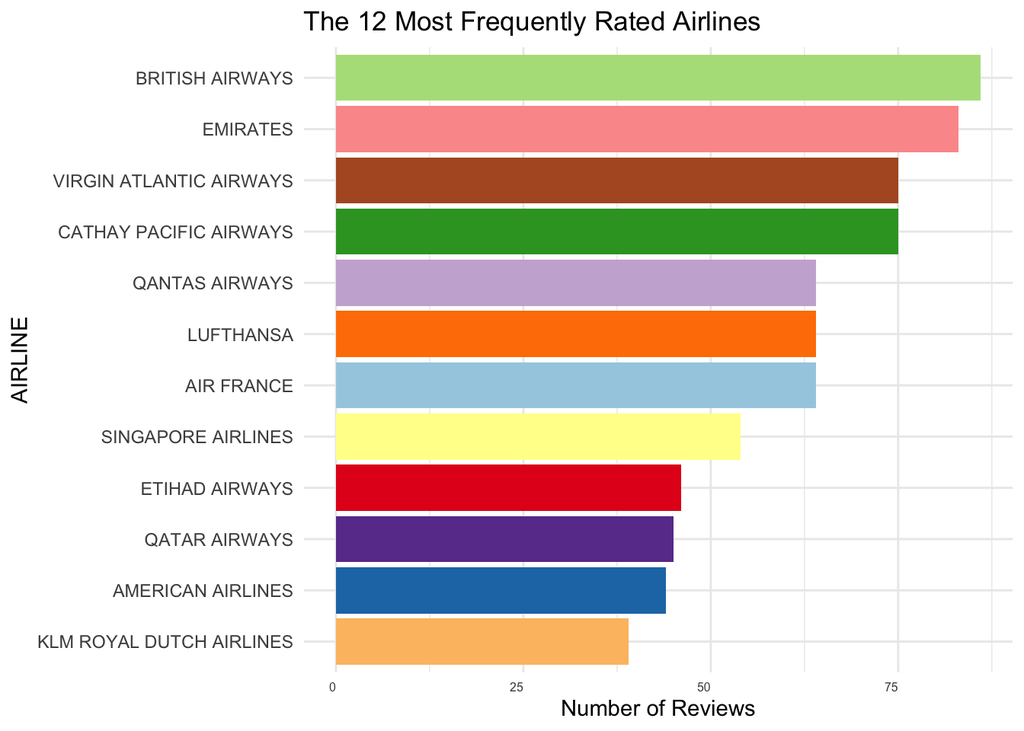

```r
by_airline %>% ggplot(aes(x = reorder(airline_name,num_of_reviews), y = num_of_reviews, fill = airline_name))+
               geom_bar(stat ="identity") +
               theme_minimal() +
               theme(axis.text.x=element_text(size=6, hjust=1),
                     axis.ticks.x=element_blank(),
                     legend.position="none") +
               scale_fill_brewer(palette = "Paired") +
               coord_flip() +
               labs(title = "The 12 Most Frequently Rated Airlines",
                    x = "AIRLINE",
                    y = "Number of Reviews")
```

The bar chart displays the twelve airlines with the most reviews (observations) in the data set - all are major names in air travel.

## QUESTION 2:

### Distribution of overall rating for top 12 most frequently rated airlines

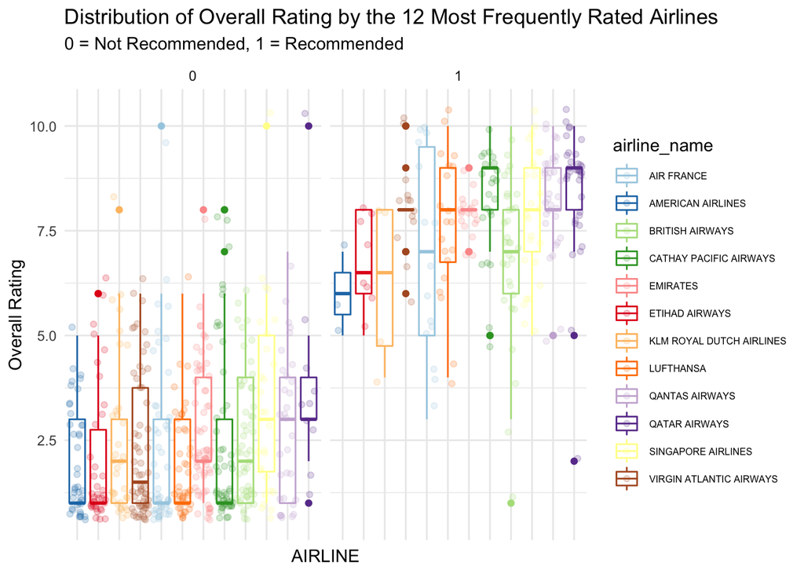

```r
most_rated_airlines <- seats_tidy %>% filter(airline_name %in% c("AIR FRANCE","AMERICAN AIRLINES","BRITISH AIRWAYS","CATHAY PACIFIC AIRWAYS","EMIRATES","ETIHAD AIRWAYS","LUFTHANSA","QANTAS AIRWAYS","QATAR AIRWAYS","SINGAPORE AIRLINES","VIRGIN ATLANTIC AIRWAYS", "KLM ROYAL DUTCH AIRLINES"))

most_rated_airlines %>% ggplot(aes( x = reorder(airline_name, overall_rating), y = overall_rating, colour = airline_name))+
                        geom_boxplot() +
                        geom_jitter(alpha = 0.2) +
                        facet_wrap(recommended~.) +
                        theme_minimal() +
                        theme(axis.text.x=element_blank(), axis.ticks.x=element_blank(), legend.text = element_text(size=6)) +
                        scale_colour_brewer(palette = "Paired") +
                        labs(title = "Distribution of Overall Rating by the 12 Most Frequently Rated Airlines",
                             subtitle = "0 = Not Recommended, 1 = Recommended",
                             x = "AIRLINE",
                             y = "Overall Rating")
```

The distribution of the Overall Rating variable is displayed separately for reviews where the passenger recommended or did not recommend the airline seat.

Notably the distribution for airlines Qatar, Qantas and Cathay Pacific indicates the best performance, in the recommended group, followed by Singapore Airlines with a wider distribution. Other airlines show either wider distribution with some lower scores, or a concentration of lower scores.

Where the passenger did not recommend their airlines seat experience most airlines have a concentration of ratings below 2.5. The box-plot for Qatar here indicates a better rating result with only some ratings below 2.5 score. Qantas and Singapore show a similar median value to Qatar, with a wider distribution.

## QUESTION 3:

#### Calculate the average (mean) of the Category Rating variables

```r
most_rated_airlines <- most_rated_airlines %>% filter(!is.na(viewing_tv_rating)) %>%
              rowwise() %>%
              mutate(mean_cat_rating = mean(seat_legroom_rating:viewing_tv_rating))

glimpse(most_rated_airlines)
```

```
## Rows: 735
## Columns: 15
## Rowwise:
## $ airline_name        <chr> "AIR FRANCE", "AIR FRANCE", "AIR FRANCE", "AIR FR…
## $ author_country      <chr> "Singapore", "United States", "United States", "U…
## $ date                <date> 2015-06-30, 2015-06-11, 2015-05-10, 2015-05-10, …
## $ aircraft_make       <chr> "BOEING", "BOEING", "AIRBUS", "AIRBUS", "BOEING",…
## $ aircraft_model      <chr> "777", "777", "A380", "A380", "777", "777", "777"…
## $ seat_layout         <chr> "3x4x3", "3x4x3", "2x3x2", "2x4x2", "2x4x2", "3x4…
## $ cabin_flown         <chr> "Economy", "Economy", "Premium Economy", "Premium…
## $ overall_rating      <dbl> 6, 10, 9, 1, 4, 8, 1, 6, 2, 1, 10, 1, 3, 6, 3, 10…
## $ seat_legroom_rating <dbl> 2, 5, 5, 2, 4, 4, 3, 3, 3, 1, 5, 1, 1, 5, 4, 5, 5…
## $ seat_recline_rating <dbl> 3, 4, 4, 1, 1, 3, 1, 2, 1, 1, 3, 1, 2, 1, 1, 1, 5…
## $ seat_width_rating   <dbl> 2, 5, 5, 3, 4, 4, 1, 3, 1, 1, 5, 1, 2, 3, 3, 1, 5…
## $ aisle_space_rating  <dbl> 5, 5, 4, 3, 3, 4, 1, 3, 2, 1, 5, 1, 1, 3, 3, 3, 5…
## $ viewing_tv_rating   <dbl> 5, 5, 3, 2, 4, 5, 1, 1, 4, 2, 5, 1, 2, 1, 3, 1, 5…
## $ recommended         <dbl> 0, 1, 1, 0, 1, 1, 0, 0, 0, 0, 1, 0, 0, 0, 0, 0, 1…
## $ mean_cat_rating     <dbl> 3.5, 5.0, 4.0, 2.0, 4.0, 4.5, 2.0, 2.0, 3.5, 1.5,…
```

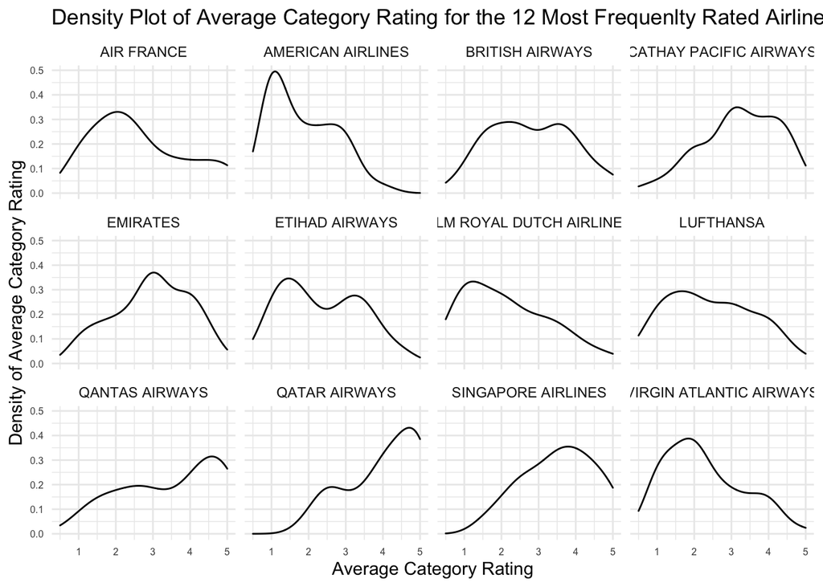

```r
most_rated_airlines %>% ggplot(aes(mean_cat_rating)) +
                        geom_density() +
                        facet_wrap(.~airline_name) +
                        theme_minimal() +
                        theme(axis.text.x=element_text(size=6),axis.text.y=element_text(size=6)) +
                        labs(title = "Density Plot of Average Category Rating for the 12 Most Frequenlty Rated Airlines",
                             x = "Average Category Rating",
                             y = "Density of Average Category Rating")
```

The density plot of Average Category Rating shows some clear contrasts. American Airlines, Virgin Atlantic, KLM Royal Dutch are all significantly skewed to the lower scores. This indicates that passengers consistently rates these seats with low scores out of five. Meanwhile Qatar, Singapore, Cathy and Qantas have high densities of higher scores and a clearly skewed in the opposite direction. The remaining airlines are more evenly distributed or peak in the middle range of scores. The difference in passenger experience and review score is very evident when comparing American Airlines to Qatar Airways.

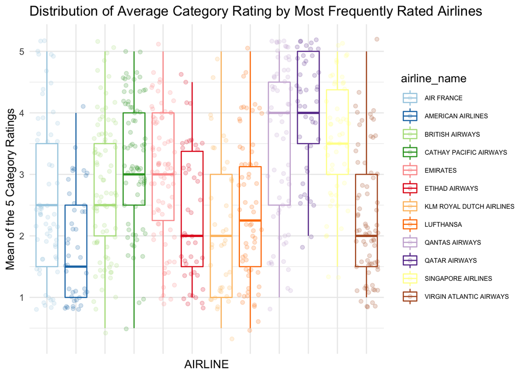

```r
most_rated_airlines %>% ggplot(aes( x = airline_name, y = mean_cat_rating, color = airline_name))+
                        geom_boxplot() +
                        geom_jitter(alpha = 0.2) +
                        theme_minimal() +
                        theme(axis.text.x=element_blank(), axis.ticks.x=element_blank(), legend.text = element_text(size=6)) +
                        scale_color_brewer(palette = "Paired") +
                        labs(title = "Distribution of Average Category Rating by Most Frequently Rated Airlines",
                             x = "AIRLINE",
                             y = "Mean of the 5 Category Ratings")
```

This box plot is an alternative visualisation the density plot above. The contrast between Qatar and Virgin Atlantic is evident - the inter-quartile range indicates that 50% of Qatar scores are concentrated between 3.5 to 5.0; while Virgin Atlantic has a median of 2.0, indicating 50% of scores are below this value.

## QUESTION 4:

### Distribtution of Overall Rating variable by Aircraft Make

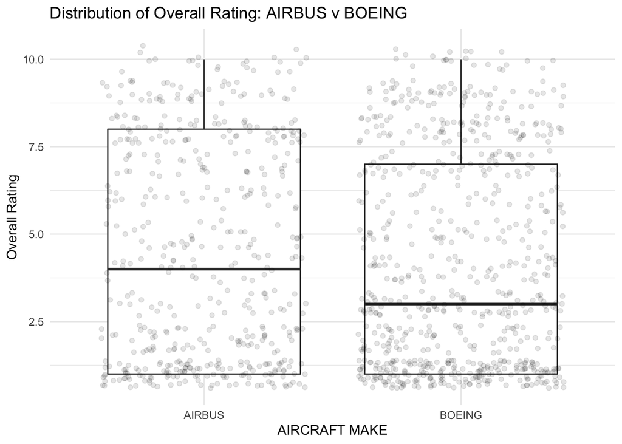

```r
seats_tidy %>% ggplot(aes( x = aircraft_make, y = overall_rating))+
               geom_boxplot() +
               geom_jitter(alpha = 0.1) +
               theme_minimal() +
               labs(title = "Distribution of Overall Rating: AIRBUS v BOEING",
                    x = "AIRCRAFT MAKE",
                    y = "Overall Rating")
```

This side-by-side box plot indicates some differences between the seat reviews of the two major aircraft manufacturers. Airbus has a slightly higher median score value and a more even distribution compared to Boeing. The plot for Boeing indicates that nearly 50% of all scores are below 2.5 and the jittered data shows a concentration of points at very low scores.

## QUESTION 5:

### Distribtution of Overall Rating variable by Aircraft Model

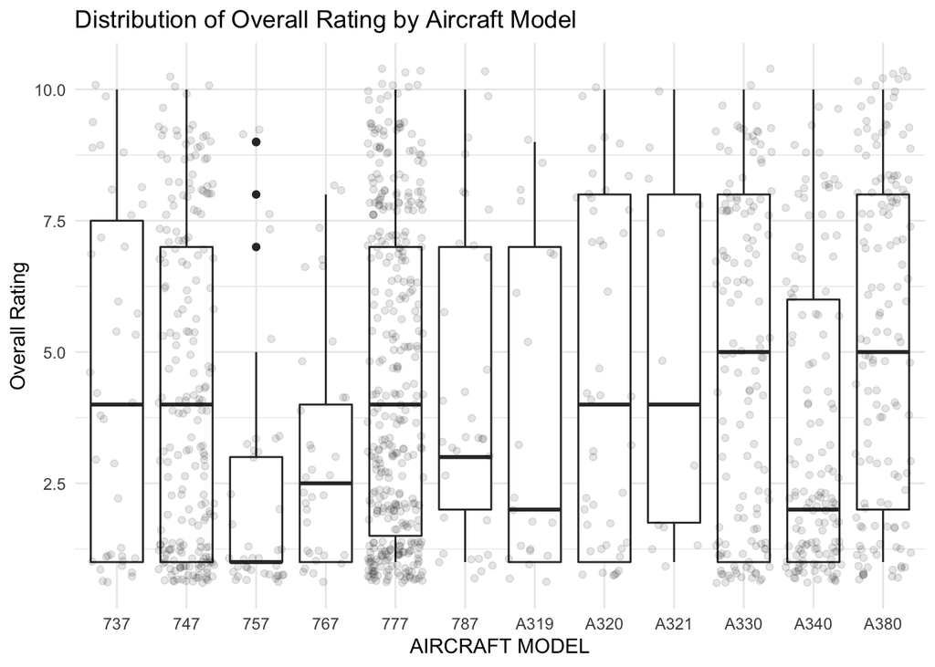

```r
seats_tidy %>% filter(aircraft_model %in% c("737","747","757","767","777","787","A319","A320","A321","A330","A340","A380")) %>%
               ggplot(aes( x = aircraft_model, y = overall_rating, group = aircraft_model))+
               geom_boxplot() +
               geom_jitter(alpha = 0.1) +
               theme_minimal() +
               labs(title = "Distribution of Overall Rating by Aircraft Model",
                    x = "AIRCRAFT MODEL",
                    y = "Overall Rating")
```

## QUESTION 6:

### Can a relationship between the some of the Average Categrory Ratings predict the Overall Rating of a seat for an airline?

#### Calculate the average (mean) of the Overall Rating variable and each Category Rating variable for each airline

```r
all_airlines_summary <- seats_tidy %>% group_by(airline_name) %>%
                        summarise(av_overall_rating = mean(overall_rating, na.rm = TRUE),
                                  av_legroom= mean(seat_legroom_rating, na.rm = TRUE),
                                  av_recline = mean(seat_recline_rating, na.rm = TRUE),
                                  av_width = mean(seat_width_rating, na.rm = TRUE),
                                  av_aspace = mean(aisle_space_rating, na.rm = TRUE),
                                  av_tv = mean(viewing_tv_rating, na.rm = TRUE)) %>%
                        arrange(desc(av_overall_rating))
all_airlines_summary
```

```
## # A tibble: 92 x 7
##    airline_name  av_overall_rati… av_legroom av_recline av_width av_aspace av_tv
##    <chr>                    <dbl>      <dbl>      <dbl>    <dbl>     <dbl> <dbl>
##  1 THOMSON AIRW…            10          5          5         5        5     5
##  2 AEGEAN AIRLI…             9.5        4          4         4        4.5   4
##  3 ICELANDAIR                9          4          4.5       4.5      4.5   4.5
##  4 GARUDA INDON…             8.6        4.5        4         4        4.2   3.9
##  5 ASIANA AIRLI…             8.56       4.56       4.19      4        4.38  4.38
##  6 BANGKOK AIRW…             8          4.5        4         4        4.5   4.5
##  7 EDELWEISS AIR             8          4          3         4        4     2
##  8 HAINAN AIRLI…             8          4          4         4        4     5
##  9 NORWEGIAN                 8          4          5         4        4     4
## 10 OMAN AIR                  8          5          4         4        4     5
## # … with 82 more rows
```

#### Plot a linear model of each Average Category Rating variable against the Average Overall Rating variable

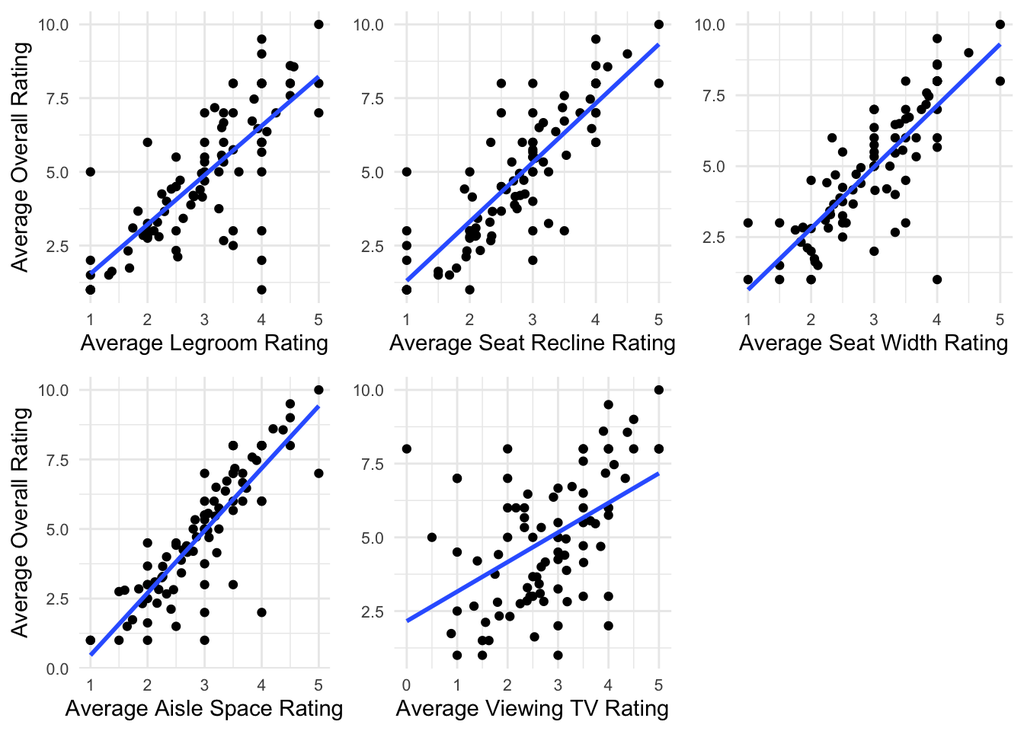

```r
lm1 <- all_airlines_summary %>% ggplot(aes(x = av_legroom, y = av_overall_rating)) +
                                geom_point() +
                                geom_smooth(method = "lm", se=FALSE) +
                                theme_minimal() +
                                theme(axis.text.x=element_text(size=8),axis.text.y=element_text(size=8)) +
                                labs( x = "Average Legroom Rating", y = "Average Overall Rating")

lm2 <- all_airlines_summary %>% ggplot(aes(x = av_recline, y = av_overall_rating)) +
                                geom_point() +
                                geom_smooth(method = "lm", se=FALSE) +
                                theme_minimal() +
                                theme(axis.text.x=element_text(size=8),axis.text.y=element_text(size=8)) +
                                labs( x = "Average Seat Recline Rating", y = NULL)

lm3 <- all_airlines_summary %>% ggplot(aes(x = av_width, y = av_overall_rating)) +
                                geom_point() +
                                geom_smooth(method = "lm", se=FALSE) +
                                theme_minimal() +
                                theme(axis.text.x=element_text(size=8),axis.text.y=element_text(size=8)) +
                                labs( x = "Average Seat Width Rating", y = NULL)

lm4 <- all_airlines_summary %>% ggplot(aes(x = av_aspace, y = av_overall_rating)) +
                                geom_point() +
                                geom_smooth(method = "lm", se=FALSE) +
                                theme_minimal() +
                                theme(axis.text.x=element_text(size=8),axis.text.y=element_text(size=8)) +
                                labs( x = "Average Aisle Space Rating", y = "Average Overall Rating")

lm5 <- all_airlines_summary %>% ggplot(aes(x = av_tv, y = av_overall_rating)) +
                                geom_point() +
                                geom_smooth(method = "lm", se=FALSE) +
                                theme_minimal() +
                                theme(axis.text.x=element_text(size=8),axis.text.y=element_text(size=8)) +
                                labs( x = "Average Viewing TV Rating", y = NULL)

grid.arrange(lm1, lm2, lm3,lm4,lm5, ncol=3)
```

#### Calculate the Correlation Coefficient between each average category variable and the Average Overall Rating variable

```r
all_airlines_summary %>% summarise(cor(av_legroom, av_overall_rating),
                                   cor(av_recline, av_overall_rating),
                                   cor(av_width, av_overall_rating),
                                   cor(av_aspace, av_overall_rating)) %>%
                                   gather("Variables","Correlation Coeff")
```

```
## # A tibble: 4 x 2
##   Variables                          `Correlation Coeff`
##   <chr>                                            <dbl>
## 1 cor(av_legroom, av_overall_rating)               0.764
## 2 cor(av_recline, av_overall_rating)               0.835
## 3 cor(av_width, av_overall_rating)                 0.818
## 4 cor(av_aspace, av_overall_rating)                0.847
```

Examining the linear model plots shows a positive correlation between each Average Category Rating variable and the Average Overall Rating. This suggests that passengers overall judgment of the airline seat is in accordance with their rating of the categories. It is clear that Average TV Viewing Rating has the weakest correlation. The highest correlation coefficients are between Overall Rating and Average Aisle Space and Average Seat Recline - arguably both key in airline seat comfort.

Three models have been considered to understand if the one or two Average Category Ratings variables can account for the variation in Average Overall Rating and predict its value.

#### Model 1: a single variable model considering Average Aisle Space Rating variable

This model was chosen as the Average Aisle Space Rating variable has the strongest correlation with Average Overall Rating

$$av.overall.rating = \beta_0 + \beta_1 av.aspace + \varepsilon$$

```r
overall_model_1 <- lm(av_overall_rating ~ av_aspace, data = all_airlines_summary)

summary(overall_model_1)
```

```
##
## Call:
## lm(formula = av_overall_rating ~ av_aspace, data = all_airlines_summary)
##
## Residuals:
##     Min      1Q  Median      3Q     Max
## -5.1827 -0.3968  0.1958  0.7139  2.0582
##
## Coefficients:
##             Estimate Std. Error t value Pr(>|t|)
## (Intercept)  -1.7811     0.4590   -3.88 0.000198 ***
## av_aspace     2.2410     0.1482   15.12  < 2e-16 ***
## ---
## Signif. codes:  0 '***' 0.001 '**' 0.01 '*' 0.05 '.' 0.1 ' ' 1
##
## Residual standard error: 1.215 on 90 degrees of freedom
## Multiple R-squared:  0.7177, Adjusted R-squared:  0.7145
## F-statistic: 228.8 on 1 and 90 DF,  p-value: < 2.2e-16
```

```r
tidy(overall_model_1)
```

```
## # A tibble: 2 x 5
##   term        estimate std.error statistic  p.value
##   <chr>          <dbl>     <dbl>     <dbl>    <dbl>
## 1 (Intercept)    -1.78     0.459     -3.88 1.98e- 4
## 2 av_aspace       2.24     0.148     15.1  1.90e-26
```

```r
glance(overall_model_1)
```

```
## # A tibble: 1 x 12
##   r.squared adj.r.squared sigma statistic  p.value    df logLik   AIC   BIC
##       <dbl>         <dbl> <dbl>     <dbl>    <dbl> <dbl>  <dbl> <dbl> <dbl>
## 1     0.718         0.715  1.22      229. 1.90e-26     1  -147.  301.  309.
## # … with 3 more variables: deviance <dbl>, df.residual <int>, nobs <int>
```

#### Model 2: an interaction beween the Average Aisle Space and Average Seat Recline ratings

This model introduces a second independent variable - Average Seat Recline.

$$av.overall.rating = \beta_0 + \beta_1 av.aspace * \beta_2 av.recline + \varepsilon$$

```r
overall_model_2 <- lm(av_overall_rating ~ av_aspace * av_recline, data = all_airlines_summary)

summary(overall_model_2)
```

```
##
## Call:
## lm(formula = av_overall_rating ~ av_aspace * av_recline, data = all_airlines_summary)
##
## Residuals:
##     Min      1Q  Median      3Q     Max
## -3.3168 -0.5174  0.0770  0.5472  2.7774
##
## Coefficients:
##                      Estimate Std. Error t value Pr(>|t|)
## (Intercept)          -1.34892    1.03292  -1.306  0.19498
## av_aspace             1.09601    0.37167   2.949  0.00408 **
## av_recline            0.78519    0.42976   1.827  0.07108 .
## av_aspace:av_recline  0.08828    0.11945   0.739  0.46180
## ---
## Signif. codes:  0 '***' 0.001 '**' 0.01 '*' 0.05 '.' 0.1 ' ' 1
##
## Residual standard error: 1.037 on 88 degrees of freedom
## Multiple R-squared:  0.7991, Adjusted R-squared:  0.7922
## F-statistic: 116.6 on 3 and 88 DF,  p-value: < 2.2e-16
```

```r
tidy(overall_model_2)
```

```
## # A tibble: 4 x 5
##   term                 estimate std.error statistic p.value
##   <chr>                   <dbl>     <dbl>     <dbl>   <dbl>
## 1 (Intercept)           -1.35       1.03     -1.31  0.195
## 2 av_aspace              1.10       0.372     2.95  0.00408
## 3 av_recline             0.785      0.430     1.83  0.0711
## 4 av_aspace:av_recline   0.0883     0.119     0.739 0.462
```

```r
glance(overall_model_2)
```

```
## # A tibble: 1 x 12
##   r.squared adj.r.squared sigma statistic  p.value    df logLik   AIC   BIC
##       <dbl>         <dbl> <dbl>     <dbl>    <dbl> <dbl>  <dbl> <dbl> <dbl>
## 1     0.799         0.792  1.04      117. 1.46e-30     3  -132.  274.  286.
## # … with 3 more variables: deviance <dbl>, df.residual <int>, nobs <int>
```

#### Model 3: an interaction between average aisle space, average seat recline and average seat width ratings

$$av.overall.rating = \beta_0 + \beta_1 av.aspace * \beta_2 av.recline * \beta_3 av.width + \varepsilon$$

```r
overall_model_3 <- lm(av_overall_rating ~ av_aspace * av_recline * av_width, data = all_airlines_summary)

summary(overall_model_3)
```

```
##
## Call:
## lm(formula = av_overall_rating ~ av_aspace * av_recline * av_width,
##     data = all_airlines_summary)
##
## Residuals:
##     Min      1Q  Median      3Q     Max
## -3.4143 -0.5041  0.0391  0.4677  2.1339
##
## Coefficients:
##                               Estimate Std. Error t value Pr(>|t|)
## (Intercept)                    1.73055    2.68517   0.644    0.521
## av_aspace                     -0.26989    1.17452  -0.230    0.819
## av_recline                    -0.07006    1.12560  -0.062    0.951
## av_width                      -1.22380    1.24900  -0.980    0.330
## av_aspace:av_recline           0.20187    0.36302   0.556    0.580
## av_aspace:av_width             0.54398    0.42473   1.281    0.204
## av_recline:av_width            0.49699    0.40969   1.213    0.228
## av_aspace:av_recline:av_width -0.11820    0.10859  -1.089    0.279
##
## Residual standard error: 0.9797 on 84 degrees of freedom
## Multiple R-squared:  0.8288, Adjusted R-squared:  0.8145
## F-statistic: 58.09 on 7 and 84 DF,  p-value: < 2.2e-16
```

```r
tidy(overall_model_3)
```

```
## # A tibble: 8 x 5
##   term                          estimate std.error statistic p.value
##   <chr>                            <dbl>     <dbl>     <dbl>   <dbl>
## 1 (Intercept)                     1.73       2.69     0.644    0.521
## 2 av_aspace                      -0.270      1.17    -0.230    0.819
## 3 av_recline                     -0.0701     1.13    -0.0622   0.951
## 4 av_width                       -1.22       1.25    -0.980    0.330
## 5 av_aspace:av_recline            0.202      0.363    0.556    0.580
## 6 av_aspace:av_width              0.544      0.425    1.28     0.204
## 7 av_recline:av_width             0.497      0.410    1.21     0.228
## 8 av_aspace:av_recline:av_width  -0.118      0.109   -1.09     0.279
```

```r
glance(overall_model_3)
```

```
## # A tibble: 1 x 12
##   r.squared adj.r.squared sigma statistic  p.value    df logLik   AIC   BIC
##       <dbl>         <dbl> <dbl>     <dbl>    <dbl> <dbl>  <dbl> <dbl> <dbl>
## 1     0.829         0.815 0.980      58.1 1.55e-29     7  -124.  267.  290.
## # … with 3 more variables: deviance <dbl>, df.residual <int>, nobs <int>
```

Model 2 is an improvement on Model 1 - the adjusted R-Squared value has increased and the value of BIC has decreased (Monash University, 2020). This indicates that Model 2 is a better fit, explaining 79.9% of the variation in the Average Overall Score. In Model 3 adding an additional independent variable has increased the value of R-Squared, however the value of BIC is greater than for Model 2. Therefore Model 2 is the preferred model (Monash University, 2020).

#### Using Model 2 to predict the Average Overall Score

$$\widehat{av.overall.rating} = 1.096 av.aspace * 0.785 av.recline - 1.349$$

```r
overall_model_2_augm <- augment(overall_model_2, all_airlines_summary) #Using augment to obtain fitted values and residuals
overall_model_2_augm
```

```
## # A tibble: 92 x 13
##    airline_name av_overall_rati… av_legroom av_recline av_width av_aspace av_tv
##    <chr>                   <dbl>      <dbl>      <dbl>    <dbl>     <dbl> <dbl>
##  1 THOMSON AIR…            10          5          5         5        5     5
##  2 AEGEAN AIRL…             9.5        4          4         4        4.5   4
##  3 ICELANDAIR               9          4          4.5       4.5      4.5   4.5
##  4 GARUDA INDO…             8.6        4.5        4         4        4.2   3.9
##  5 ASIANA AIRL…             8.56       4.56       4.19      4        4.38  4.38
##  6 BANGKOK AIR…             8          4.5        4         4        4.5   4.5
##  7 EDELWEISS A…             8          4          3         4        4     2
##  8 HAINAN AIRL…             8          4          4         4        4     5
##  9 NORWEGIAN                8          4          5         4        4     4
## 10 OMAN AIR                 8          5          4         4        4     5
## # … with 82 more rows, and 6 more variables: .fitted <dbl>, .resid <dbl>,
## #   .std.resid <dbl>, .hat <dbl>, .sigma <dbl>, .cooksd <dbl>
```

Qatar Airways has an Average Overall Rating of 7.467 and a fitted value of 7.359. Therefore a residual of 0.107

American Airlines has an Average Overall Rating of 2.318 and a fitted value of 2.607. Therefore a residual of -0.283

Overall, it can be seen that Model 2 gives very reasonable predictions for Average Overall Rating for an airline seat.

# **SUMMARY OF RESULTS**

The analysis and visualisations of the airline passenger seat reviews has shown a significant variation in the Overall Rating performance for the twelve most frequently rated Airlines for Question 1. Nine of these airlines had an Average Overall Rating below 5.0. Qatar Airways had the highest Average Overall Rating.

The side-by-side box plots and density plots displayed the results for Question 2 and 3. The performance of each airline in terms of passenger seat review varies considerably. American Airlines, Virgin Atlantic, KLM Royal Dutch are all significantly skewed to the lower scores. This indicates that passengers consistently rates these seats with low scores out of five. Meanwhile Qatar, Singapore, Cathy and Qantas have high densities of higher scores demonstrated scores suggesting a very different passenger seat experience to the other airlines in the group of twelve most rated.

In response to Question 6 three models were considered and Model 2 was selected as the preferred model. Model 2 accounted for 79.9% of the variation in Average Overall Rating using two independent variables and had a lower BIC that Model 3. Augmenting the fitted showed the model gave very reasonable predictions of Average Overall Rating. This indicates that Aisle Space and Seat Recline are very important to airline passengers and how they rate their seat experience.

# **CONCLUSION**

This report aimed to answer six questions relating to the SkyTrax airline passenger seat reviews data. A tidy data set of 1,226 observations across 14 variables was used to visualise and model responses to the questions. Overall, the performance of the most frequently rated airlines was shown to vary considerably. The methods and visual plots used in response to each question allowed for some discussion in relation to each question. Moreover, average passenger ratings across key categories were shown to strongly correlate with the average overall seat rating of the airline seat. A simple linear model with two independent variables was shown to predict the average overall rating.

# **REFERENCES**

Chang, Winston., Dunnington,Dewey., Henry, Lionel., Pedersen, Thomas Lin., Takahashi, Kohske Wickham,Hadley., Wilke,Claus., Woo,Kara., Yutani, Hiroaki. (n.d). ggplot2: part of the tidyverse. Retrieved from https://ggplot2.tidyverse.org/reference/index.html

Grolemund, Garrett., Wickham, Hadley. (n.d). R for Data Science. Retrieved from https://r4ds.had.co.nz

Hayes, Alex. (2020). broom: Convert Statistical Objects into Tidy Tibbles. Retrieved from https://CRAN.R-project.org/package=broom

Monash University. (2020). Goodness of fit. Retrieved from https://www.futurelearn.com/courses/data-science-modelling-and-visualisation/4/steps/869615

SkyTrax. (n.d). Our Background. Retrieved from https://www.airlinequality.com/about-us/

Skytrax User Reviews Dataset. (2015). Retrieved from https://github.com/quankiquanki/skytrax-reviews-dataset

Tierney, Nicholas. (2019). Using Visdat. Retrieved from https://cran.r-project.org/web/packages/visdat/vignettes/using_visdat.html

Wickham, Hadley., François, Romain.,Henry, Lionel., Müller, Kirill. (n.d). Row-wise Operations. Retrieved from https://dplyr.tidyverse.org/articles/rowwise.html

Wickham, Hadley.(2019). Remove Matched Patterns In A String. Retrieved from https://www.rdocumentation.org/packages/stringr/versions/1.4.0/topics/str_remove

Wickham, Hadley.(2019). Replace Matched Patterns In A String. Retrieved from https://www.rdocumentation.org/packages/stringr/versions/1.4.0/topics/str_replace

Wickham, Hadley., François, Romain., Henry, Lionel., Müller, Kirill. (n.d). Vectorised If. Retrieved from https://dplyr.tidyverse.org/reference/if_else.html

Xie, Yihui., Allaire, J.J., Grolemund, Garrett. (2020). R Markdown: The Definitive Guide. Retrieved from https://bookdown.org/yihui/rmarkdown/html-document.html